# Predicting Car Prices Based on Certain Characteristics

DSCI310 Group 07: Harbor Zhang, Jiaying Liao, Ning Wang, Xiwen Wei

2023-04-10

Original Project Authors: Henry Zhang, Moira Renata, Ning Wang, Paige Wills, Xinrui Wang in STAT 301 Group 36.

# 1 Introduction

Over the past few decades, we have seen a rapid increase in demand for the car industry. The high market price of both brand new and used cars have created a large economic impact all over the world. Based on previous studies, it was found that there are multiple factors affecting the final price of a car (Balce 2016) and that while most factors do have a positive contribution or effect to the final price, there are still some factors that create a negative effect (Erdem and Şentürk 2009). Moreover, according to previous studies, the car price one of the most significant factor when people deciding whether to purchase a car(Armstrong 2022).

Therefore, in this project, we hope to create a model that allows us to predict the final price of a car given its characteristics.

# 2 Description

| Variable | Type | Description |
| --- | --- | --- |
| symboling | Categorical | Assigned insurance risk rating |
| normalized-losses | Numerical | Relative average loss payment per insured vehicle year in dollars (USD) |
| make | Categorical | Car manufacturer/model |
| fuel-type | Categorical | Type of fuel to power car |
| aspiration | Categorical | Engine aspiration (std, turbo) |
| num-of-doors | Numerical | Number of doors |
| body-style | Categorical | Car’s style (sedan, convertible, etc.) |
| drive-wheels | Categorical | amount and location of wheels |
| engine-location | Categorical | Engine location (front, back) |
| wheel-base | Numerical | Horizontal distance between the front and rear wheel in inches. |
| length | Numerical | Length of car in inches |
| width | Numerical | Width of car in inches |
| height | Numerical | Height of car in inches |
| curb-weight | Numerical | Weight of car in pounds |
| engine-type | Categorical | Engine type (dohc, dohcv, etc.) |
| num-of-cylinders | Categorical | Number of cylinders in engine |
| Engine-size | Numerical | Engine size in cubic inches |
| fuel-system | Categorical | Fuel system in car (1bbl, mfi. etc.) |
| bore | Numerical | Diameter of each cylinder in inches |
| stroke | Numerical | Movement of piston in gigapascal |
| compression-ratio | Numerical | Ratio between the cylinder’s highest and lowest volumes at the bottom and top of the piston’s stroke. |
| horsepower | Numerical | Engine horsepower (hp) |
| peak-rpm | Numerical | RPM at which engine delivers peak horsepower |
| city-mpg | Numerical | Mileage in the city in miles per gallon |
| highway-mpg | Numerical | Mileage in the highway in miles per gallon |
| price | Numerical | Price of car in USD ($) |

# 3 Preliminary Analysis

In this section, we load and clean the data. Note that the all `?` are replaced with `NA`.

Table 3.1: Automobile Dataset

| symboling | normalized-losses | make | fuel-type | aspiration | num-of-doors | body-style | drive-wheels | engine-location | wheel-base | length | width | height |
| --- | --- | --- | --- | --- | --- | --- | --- | --- | --- | --- | --- | --- |
| 3 |  | alfa-romero | gas | std | two | convertible | rwd | front | 88.6 | 168.8 | 64.1 | 48.8 |
| 3 |  | alfa-romero | gas | std | two | convertible | rwd | front | 88.6 | 168.8 | 64.1 | 48.8 |
| 1 |  | alfa-romero | gas | std | two | hatchback | rwd | front | 94.5 | 171.2 | 65.5 | 52.4 |
| 2 | 164 | audi | gas | std | four | sedan | fwd | front | 99.8 | 176.6 | 66.2 | 54.3 |
| 2 | 164 | audi | gas | std | four | sedan | 4wd | front | 99.4 | 176.6 | 66.4 | 54.3 |
| 2 |  | audi | gas | std | two | sedan | fwd | front | 99.8 | 177.3 | 66.3 | 53.1 |

| curb-weight | engine-type | num-of-cylinders | engine-size | fuel-system | bore | stroke | compression-ratio | horsepower | peak-rpm | city-mpg | highway-mpg | price |
| --- | --- | --- | --- | --- | --- | --- | --- | --- | --- | --- | --- | --- |
| 2548 | dohc | four | 130 | mpfi | 3.47 | 2.68 | 9.0 | 111 | 5000 | 21 | 27 | 13495 |
| 2548 | dohc | four | 130 | mpfi | 3.47 | 2.68 | 9.0 | 111 | 5000 | 21 | 27 | 16500 |
| 2823 | ohcv | six | 152 | mpfi | 2.68 | 3.47 | 9.0 | 154 | 5000 | 19 | 26 | 16500 |
| 2337 | ohc | four | 109 | mpfi | 3.19 | 3.40 | 10.0 | 102 | 5500 | 24 | 30 | 13950 |
| 2824 | ohc | five | 136 | mpfi | 3.19 | 3.40 | 8.0 | 115 | 5500 | 18 | 22 | 17450 |
| 2507 | ohc | five | 136 | mpfi | 3.19 | 3.40 | 8.5 | 110 | 5500 | 19 | 25 | 15250 |

From tables 3.1, we noticed that there are some NA values. Each row represents an observation, each column is a variable, and each cell is a value, which means there is not a lot of data tidying to do. We will first check the number of NA values in each column, the number of levels in columns that are categorical variables, and the summary statistics of each variable.

Table 3.2: Summary of Automobile Dataset

| symboling | 3 :27 | 1 :54 | 2 :32 | 0 :67 | -1:22 | -2: 3 |  |
| --- | --- | --- | --- | --- | --- | --- | --- |
| normalized-losses | Min. : 65 | 1st Qu.: 94 | Median :115 | Mean :122 | 3rd Qu.:150 | Max. :256 | NA’s :41 |
| make | toyota : 32 | nissan : 18 | mazda : 17 | honda : 13 | mitsubishi: 13 | subaru : 12 | (Other) :100 |
| fuel-type | gas :185 | diesel: 20 |  |  |  |  |  |
| aspiration | std :168 | turbo: 37 |  |  |  |  |  |
| num-of-doors | two : 89 | four:114 | NA : 2 |  |  |  |  |
| body-style | convertible: 6 | hatchback :70 | sedan :96 | wagon :25 | hardtop : 8 |  |  |
| drive-wheels | rwd: 76 | fwd:120 | 4wd: 9 |  |  |  |  |
| engine-location | front:202 | rear : 3 |  |  |  |  |  |
| wheel-base | Min. : 86.60 | 1st Qu.: 94.50 | Median : 97.00 | Mean : 98.76 | 3rd Qu.:102.40 | Max. :120.90 |  |
| length | Min. :141.1 | 1st Qu.:166.3 | Median :173.2 | Mean :174.0 | 3rd Qu.:183.1 | Max. :208.1 |  |
| width | Min. :60.30 | 1st Qu.:64.10 | Median :65.50 | Mean :65.91 | 3rd Qu.:66.90 | Max. :72.30 |  |
| height | Min. :47.80 | 1st Qu.:52.00 | Median :54.10 | Mean :53.72 | 3rd Qu.:55.50 | Max. :59.80 |  |
| curb-weight | Min. :1488 | 1st Qu.:2145 | Median :2414 | Mean :2556 | 3rd Qu.:2935 | Max. :4066 |  |
| engine-type | dohc : 12 | ohcv : 13 | ohc :148 | l : 12 | rotor: 4 | ohcf : 15 | dohcv: 1 |
| num-of-cylinders | four :159 | six : 24 | five : 11 | three : 1 | twelve: 1 | two : 4 | eight : 5 |
| engine-size | Min. : 61.0 | 1st Qu.: 97.0 | Median :120.0 | Mean :126.9 | 3rd Qu.:141.0 | Max. :326.0 |  |
| fuel-system | mpfi :94 | 2bbl :66 | idi :20 | 1bbl :11 | spdi : 9 | 4bbl : 3 | (Other): 2 |
| bore | Min. :2.54 | 1st Qu.:3.15 | Median :3.31 | Mean :3.33 | 3rd Qu.:3.59 | Max. :3.94 | NA’s :4 |
| stroke | Min. :2.070 | 1st Qu.:3.110 | Median :3.290 | Mean :3.255 | 3rd Qu.:3.410 | Max. :4.170 | NA’s :4 |
| compression-ratio | Min. : 7.00 | 1st Qu.: 8.60 | Median : 9.00 | Mean :10.14 | 3rd Qu.: 9.40 | Max. :23.00 |  |
| horsepower | Min. : 48.0 | 1st Qu.: 70.0 | Median : 95.0 | Mean :104.3 | 3rd Qu.:116.0 | Max. :288.0 | NA’s :2 |
| peak-rpm | Min. :4150 | 1st Qu.:4800 | Median :5200 | Mean :5125 | 3rd Qu.:5500 | Max. :6600 | NA’s :2 |
| city-mpg | Min. :13.00 | 1st Qu.:19.00 | Median :24.00 | Mean :25.22 | 3rd Qu.:30.00 | Max. :49.00 |  |
| highway-mpg | Min. :16.00 | 1st Qu.:25.00 | Median :30.00 | Mean :30.75 | 3rd Qu.:34.00 | Max. :54.00 |  |
| price | Min. : 5118 | 1st Qu.: 7775 | Median :10295 | Mean :13207 | 3rd Qu.:16500 | Max. :45400 | NA’s :4 |

According to table 3.2, there are 45 rows that contain NA values. And the number of rows that have complete observations are 160.

# 4 Exploratory Data Analysis

Next, we will perform EDA to better understand the variables that we will be using in our analysis.

It would be beneficial to visualize the pairwise correlation coefficients of our dataset to check for multicollinearity. This can be done either by using the `ggpairs` function, or by creating a correlation heatmap. However, since our data contains mulitple categorical variables with a large number of levels, this is not possible to do at this point. Therefore, our EDA is limited to checking the Coefficient of Determination of all the predictor variables and visualizing the relationship of the top 8 predictor variables based on their $R^2$ value.

Firstly, we want to calculate the coefficient of determination of all of our predicted variables.

Table 4.1: The 8 variables with highest $R^2$

| R^2 | names |
| --- | --- |
| 0.796 | make |
| 0.761 | engine-size |
| 0.696 | curb-weight |
| 0.657 | horsepower |
| 0.63 | num-of-cylinders |
| 0.564 | width |
| 0.497 | highway-mpg |
| 0.477 | length |

Based on the result in table 4.1, the variable that has the highest $R^2$ value is `make` with a value of 0.796. This can be interpreted as 79.6% of the variation observed in `price` is explained by the model with `make` as the explanatory variable.

Then, we created plots for the top 8 predictor variables. For the numerical variables, we created both a histogram to see the distribution, and a scatter plot to see the relationship between the variable and the car price. For the categorical variables, we created a bar graph to compare the count of each category in a variable. Analysis of the plots created are written after the code.

Analysis on the plots:

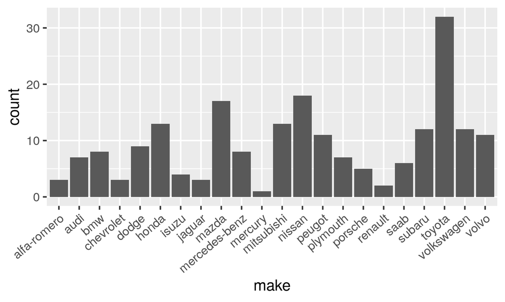

Figure 4.1: Distribution of make

- For the variable `make` (see Figure 4.1), we can see that Japanese brands, such as Toyota, Nissan and Mazada have the top 3 counts, which means they produce the most cars.

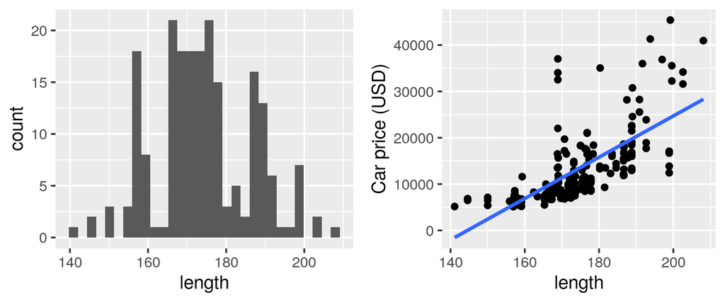

Figure 4.2: Distribution of length and price vs length

- For the variable `length` (see Figure 4.2), we can see the distribution is approximately normal and has a positive linear relationship with `price`.

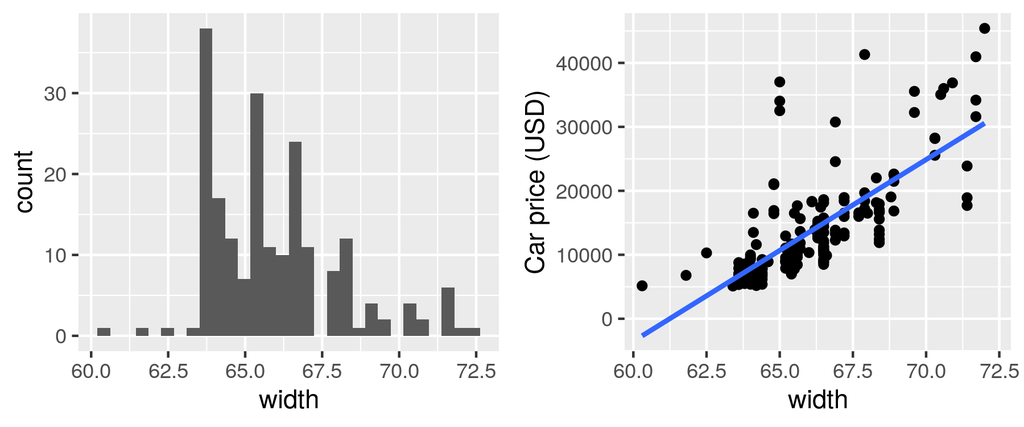

Figure 4.3: Distribution of width and price vs width

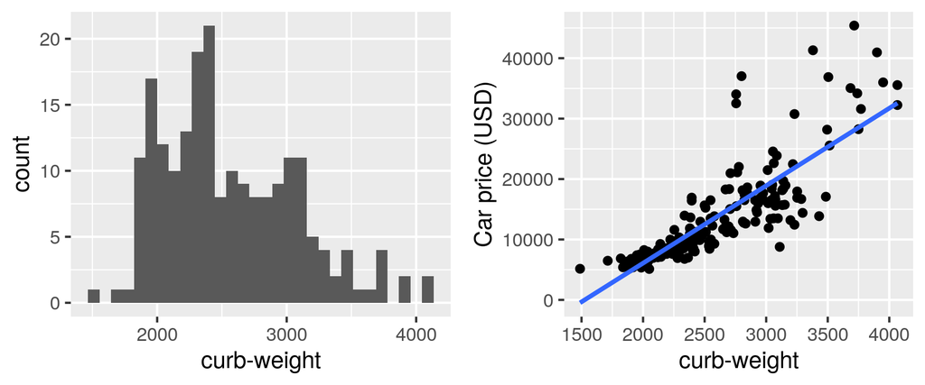

Figure 4.4: Distribution of car weight and price vs weight

- For the variable `curb-weight` (see Figure 4.4), we can see the distribution is skewed to right and has a positive linear relationship with `price`.

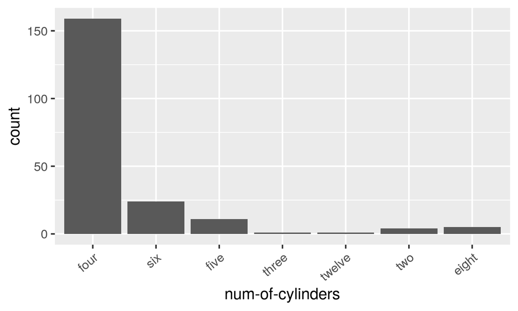

Figure 4.5: Distribution of number of cylinders

- For the variable `num-of-cylinders` (see Figure 4.5), we can see that most cars have 4-cylinders.

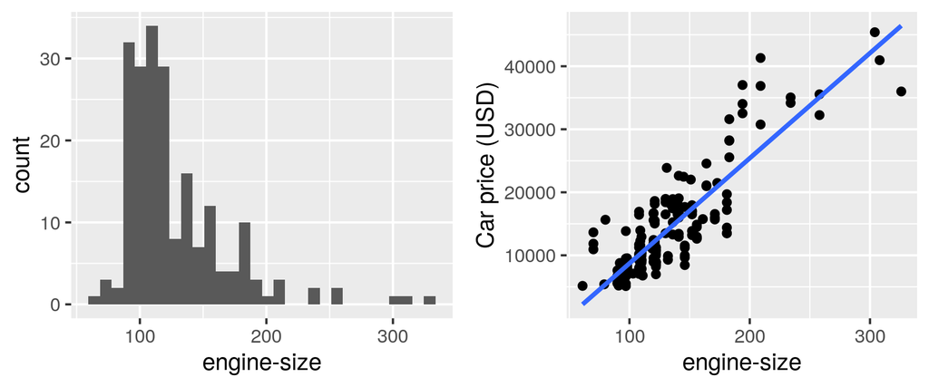

Figure 4.6: Distribution of engine size and price vs engine size

- For the variable `engine-size` (see Figure 4.6), we can see the distribution is skewed to right and has a positive linear relationship with `price`.

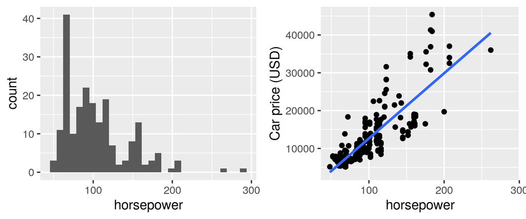

Figure 4.7: Distribution of horse power and price vs horse power

- For the variable `horse-power` (see Figure 4.7), we can see the distribution is skewed to right and has a positive linear relationship with `price`.

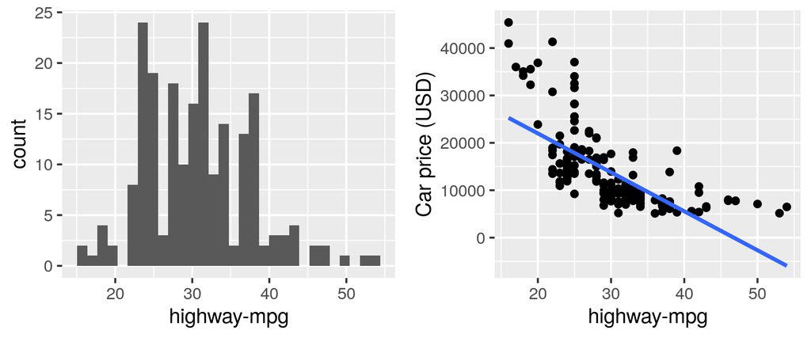

Figure 4.8: Distribution of highway mpg and Price vs highway mpg

- For the variable `highway-mpg` (see Figure 4.8), we can see the distribution is approximately normal and has a negative linear relationship with `price`.

# 5 Methods

Table 5.1: Levels of all variables

| num_unique | type |
| --- | --- |
| 6 | factor |
| 51 | numeric |
| 18 | factor |
| 2 | factor |
| 2 | factor |
| 2 | factor |
| 5 | factor |
| 3 | factor |
| 1 | factor |
| 40 | numeric |
| 56 | numeric |
| 33 | numeric |
| 39 | numeric |
| 136 | numeric |
| 5 | factor |
| 5 | factor |
| 32 | numeric |
| 6 | factor |
| 33 | numeric |
| 31 | numeric |
| 29 | numeric |
| 48 | numeric |
| 20 | numeric |
| 25 | numeric |
| 28 | numeric |
| 145 | numeric |

Apart from that, after we omit NA, the levels of engine-location appears to be 1. This will cause contrasts since we need a categorical variables to be factors with 2 or more levels. Thus we need to remove `engine-location`.

Then, the data set is split into two data sets - training and testing using a 70-30% basis and the ID variables are removed.

We then create new training and testing datasets that excludes the variables listed. We call them:

1. `training_df_sub`
2. `testing_df_sub`

This code prepares the dataset(s) for `glmnet()` which only takes matrices (hence `model.matrix`). The `glmnet()` function has an argument `object`, which is the formula of the model and therefore needs clear x and y variables, explaining why the training and testing datasets are split into subsets of x and y.

Now our data is prepared for the `glmnet()` function, we will use `cv.glmnet` to obtain the optimal value of lambda using the training set. Since this is a LASSO model, we will use the argument `alpha=1` and `n.folds=10` to find the optimal value of lambda using cross-validation by defining a sequence of values.

Then the plot function will be used to visualise the MSE of different lambdas.

`lasso_mod` provides the $\hat{\lambda}_{\text{min}}$ for LASSO (explained below) and `lasso_mod_1se` provides the $\hat{\lambda}_{\text{1SE}}$ for LASSO (explained below).

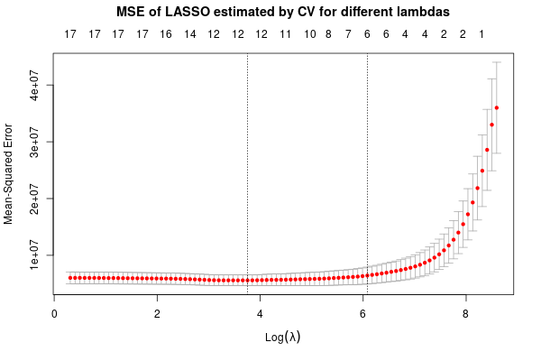

Figure 5.1: Lasso Regression

Figure 5.1 shows the estimated test MSE on the y-axis for a grid of values of ${\lambda}$ on the x-axis (on a natural log-scale). The two vertical dotted lines show us where lambda is minimized, in other words, how many variables are needed for the best model. The numbers on the top x-axis indicate the number of input variables whose estimated coefficients are different for 0 for different values of lambda. The error bars represent the variation across the different sets of the CV folds. The left line shows $\hat{\lambda}_{\text{min}}$ - which is the minimum MSE in the grind and the right line represents $\hat{\lambda}_{\text{1SE}}$ - which is the largest values of lambda such that the corresponding MSE is still within 1 standard error of that of the minimum (more penalization at low cost).

A similar method is followed for Ridge, except `alpha = 0`. `ridge_mod` provides the $\hat{\lambda}_{\text{min}}$ for Ridge and `ridge_mod_1se` provides the $\hat{\lambda}_{\text{1SE}}$ value for Ridge (explained above).

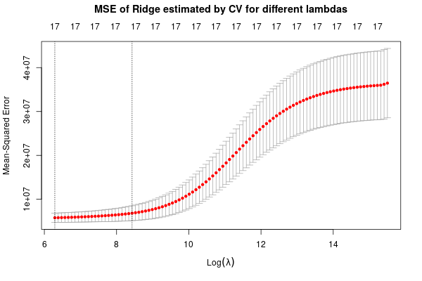

Figure 5.2: Ridge Regression

Figure 5.2 for Ridge regression shows the estimated test MSE for each value of lambda, just like that of LASSO. However the main difference here is that the top x-axis is all the same value - 17. This is because the Ridge estimator never shrinks estimates to 0, unlike LASSO. The two vertical lines represent $\hat{\lambda}_{\text{min}}$ and $\hat{\lambda}_{\text{1SE}}$ with the x and y axis being the same as LASSO.

For explanatory analysis purposes, we will be using both $\hat{\lambda}_{\text{min}}$ and $\hat{\lambda}_{\text{1SE}}$ for both LASSO and Ridge to create four different regression models. Additionally, we also be creating an OLS model for comparison. The 5 models we will be creating are listed below:

1. `mod_lasso`: LASSO regression using $\lambda$ = $\hat{\lambda}_{\text{min}}$ from LASSO
2. `mod_lasso_1se`: LASSO regression using $\lambda$ = $\hat{\lambda}_{\text{1SE}}$ from LASSO
3. `ridge_mod`: Ridge regression using $\lambda$ = $\hat{\lambda}_{\text{min}}$ from Ridge
4. `ridge_mod_1se`: Ridge regression using $\lambda$ = $\hat{\lambda}_{\text{1SE}}$ from Ridge
5. `ols_fs`: Ordinary least squares full regression using $\lambda$ = 0

After creating the 5 models, we will then obtain the out-of-sample predictions for the test sets of all five different models above, shown by `preds_1`, `preds_2`, `preds_3`, `preds_4` and `preds_5`.

Finally, we are able to compute the RMSE (root mean squared error) to evaluate the predicted models, which is clearly summarised in the tibble below.

Table 5.2: Cross-Validation Result

| Model | R_MSE |
| --- | --- |
| LASSO Regression with minimum MSE | 671.366 |
| LASSO Regression with 1SE MSE | 810.066 |
| Ridge Regression with minimum MSE | 658.405 |
| LASSO Regression with 1SE MSE | 845.964 |
| OLS Full Regression | 1052.463 |

Through the 10 fold cross validation error (root mean squared error) in table 5.2, RMSE are in the same scale across all models. Therefore, due to model simplicity and robustness to outliers, we decide to use the LASSO Regression model with 1se MSE for our final predictions.

Beside that, we obtained a root mean squared prediction error of 578.754 when using the LASSO Regression model on the test set.

Table 5.3: Kept variables

| kept_variables | coefficient |
| --- | --- |
| (Intercept) | -15273.682 |
| width | 113.379 |
| `curb-weight` | 7.310 |
| horsepower | 13.261 |

Taking a look at the coefficients of our model in table 5.3, we noticed that the LASSO model had selected only three variables, which are `width`, `curb-weight`, and `horsepower`, while all the coefficients of other input variables were reduced to 0.

# 6 Discussion

Our goal requires generating a prediction model with potential independent variables that can predict the price of the car. Based on our exploratory data analysis and regression model comparisons, we chose the LASSO model with $\hat{\lambda}_{\text{1SE}}$ , which we expect to have good prediction performance.

## 6.1 Summary

Based on the results above, the variables `width`,`curb-weight`, and `horsepower` were chosen by the LASSO model. With `lasso_mod_1se` (more penalization at a low cost) to penalize, all of the other regression coefficients of the input variables were shrunk to 0. If we refer back to our EDA, we notice that the three variables selected by LASSO are included in the list of top 8 variables with the highest coefficient of determination. However, it was surprising to see that there were only 3 predictor variables in our final LASSO model, which means all the other variables were shrunk to 0. Some variables that we thought were going to be important, like `city-mpg`, `length`, and `height` were surprisingly not included in the final model.

LASSO penalizes the residual sum of squares with $L_1$ penalty, and the penalty parameter $\hat{\lambda}_{\text{1SE}}$ that we chose was selected through a process called tuning in order to avoid using the test set when creating our model. Although this shrinkage method (LASSO) might lead to bias of the estimated coefficients, we sacrifice this for a lower variance to gain better prediction performance and robustness in our model.

We hope that this fitted LASSO model will allow users to predict the price of a car in USD based on the 3 variables that were selected. Although we initially expected to have more predictor variables, we believe that the 3 predictor variables can give a rough prediction of the price of a car (USD). Moreover, we believe such a model could not only provide the expected price of a new car to customers, but also help sellers of second-hand cars set ideal prices.

## 6.2 Further Questions and Improvements

There are two main problems that need to be improved:

1. Using high-level (N >2) categorical variables in the LASSO model. The LASSO model interprets N-1 dummy variables as its own separate variable, which may exclude certain levels. To deal with this issue, we dropped the variables with high levels. However by doing so, we might have dropped a statistically significant variable. In future research, maybe by using another regression model, including those categorical variables with more than 2 levels, we can improve our model’s performance.
2. Another problem involves LASSO’s biased estimators. In the future, if we want to generate an inference model, we can apply post-lasso. This is done by fiting a regular least squares model to the variables selected by LASSO.

# References

Armstrong, M. 2022. “Most Important Factors When Buying a Car.” Digital image. https://www.statista.com/chart/13075/most-important-factors-when-buying-a-car/.

Balce, Andım Oben. 2016. “Factors Affecting Prices in an Used Car e-Market.” *Journal of Internet Applications and Management* 7 (2): 5–20. https://doi.org/10.5505/iuyd.2016.30974.

Erdem, Cumhur, and İsmail Şentürk. 2009. “A Hedonic Analysis of Used Car Prices in Turkey.” *International Journal of Economic Perspectives* 3 (January): 141–49.

Schlimmer, Jeffrey C. 1987. “Automobile Data Set.” Machine Learning Repository. https://archive.ics.uci.edu/ml/datasets/Automobile.